# PA 2: Using Data Visualization to Find the Group

# Part One

1. Install and load the **openintro** package.

```r
library(openintro)
```

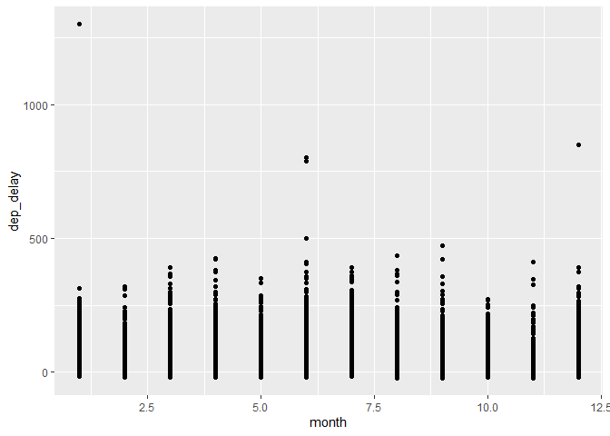

```r
ggplot(data = nycflights) +
  geom_point(mapping = aes(x = month, y = dep_delay))
```

**Checkpoint:** This plot should be unsatisfying! Think critically about a better way to visualize this relationship.

*Hint:* Think about what type of variable `month` behaves like!

# Part Two

In order to create the plot we want, `month` needs to be a character variable, not a numeric variable. Write the code to convert `month` into a character data type.

```r
nycflights <- nycflights %>%
  mutate(month = as.character(month)
         )
```

1. Create a visualization of the relationship between the departure delay (`dep_delay`) and the month of the departure (`month`) that allows for you to see the **shape** of the distribution of the departure delays.

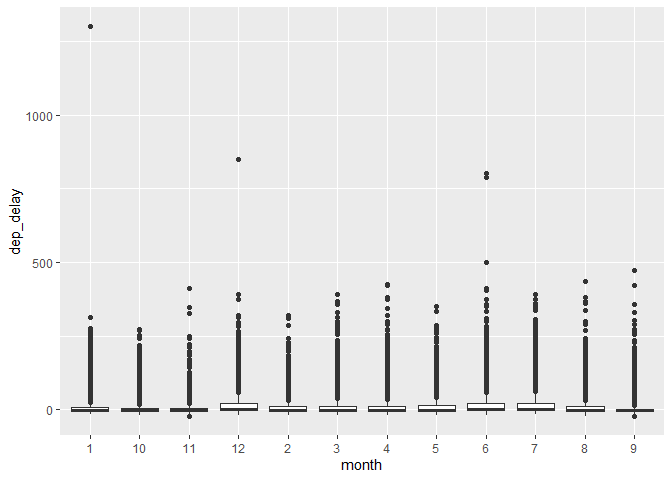

```r
ggplot(data = nycflights,
       mapping = aes(y = dep_delay, x = month)
       ) +
  geom_boxplot()
```

2. Add the origin of the flight (`origin`) to your visualization.

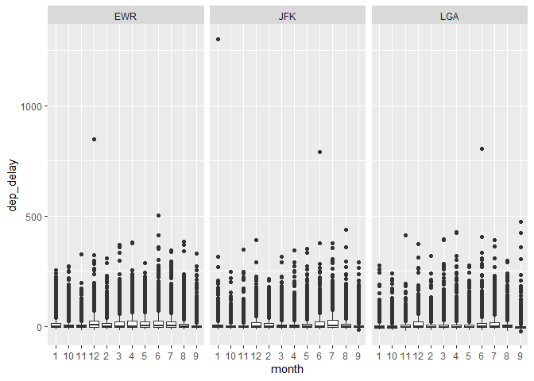

```r
# Option 1 -- facets
ggplot(data = nycflights,
       mapping = aes(y = dep_delay, x = month)) +
  geom_boxplot() +
  facet_wrap(~ origin)
```

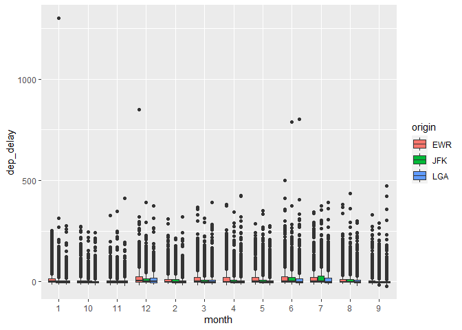

```r
# Option 2 -- color
ggplot(data = nycflights,
       mapping = aes(y = dep_delay, x = month, fill = origin)) +
  geom_boxplot()
```

# Part Three

Use your final plot to address the following questions:

1. During what month did the **second** longest delay occur at EWR?

**Month = 6; June**

2. During what month did the **second** longest delay occur at JFK?

**Month = 6; June**

3. During what month did the **second** longest delay occur at LGA?

**Month = 9 ; September**